# Analyze_ab_test_results_notebook

## Analyze A/B Test Results

- Introduction
- Part I - Probability
- Part II - A/B Test
- Part III - Regression

### Introduction

For this project, you will be working to understand the results of an A/B test run by an e-commerce website. Your goal is to work through this notebook to help the company understand if they should implement the new page, keep the old page, or perhaps run the experiment longer to make their decision.

**As you work through this notebook, follow along in the classroom and answer the corresponding quiz questions associated with each question.** The labels for each classroom concept are provided for each question. This will assure you are on the right track as you work through the project, and you can feel more confident in your final submission meeting the criteria. As a final check, assure you meet all the criteria on the [RUBRIC](https://review.udacity.com/#!/projects/37e27304-ad47-4eb0-a1ab-8c12f60e43d0/rubric).

#### Part I - Probability

To get started, let's import our libraries.

```python
import pandas as pd
import numpy as np
import random
import seaborn as sns
import matplotlib.pyplot as plt
%matplotlib inline
#We are setting the seed to assure you get the same answers on quizzes as we set up
random.seed(42)
```

`1.` Now, read in the `ab_data.csv` data. Store it in `df`. **Use your dataframe to answer the questions in Quiz 1 of the classroom.**

a. Read in the dataset and take a look at the top few rows here:

```python
df = pd.read_csv('ab_data.csv')
```

```python
df.head()
```

|  | user_id | timestamp | group | landing_page | converted |
| --- | --- | --- | --- | --- | --- |
| 0 | 851104 | 2017-01-21 22:11:48.556739 | control | old_page | 0 |
| 1 | 804228 | 2017-01-12 08:01:45.159739 | control | old_page | 0 |
| 2 | 661590 | 2017-01-11 16:55:06.154213 | treatment | new_page | 0 |
| 3 | 853541 | 2017-01-08 18:28:03.143765 | treatment | new_page | 0 |
| 4 | 864975 | 2017-01-21 01:52:26.210827 | control | old_page | 1 |

b. Use the below cell to find the number of rows in the dataset.

```python
records=df.shape[0]
print('Nr. of records: ', records)
```

```
Nr. of records:  294478
```

c. The number of unique users in the dataset.

```python
unique_users=df['user_id'].drop_duplicates().count()
print('Nr. of unique users: ', unique_users)
```

```
Nr. of unique users:  290584
```

d. The proportion of users converted.

```python
converted_users=df[df['converted']==True]['user_id'].drop_duplicates().count()
```

```python
print('Proportion of users converted: ', converted_users/unique_users)
```

```
Proportion of users converted:  0.12104245244060237
```

e. The number of times the `new_page` and `treatment` don't line up.

```python
#non matching landing page
non_matching = df[(df['group']=='treatment') & (df['landing_page'] != 'new_page')].shape[0]
```

```python
#non matching group
non_matching += df[(df['group']!='treatment') & (df['landing_page'] == 'new_page')].shape[0]
```

```python
print('Nr. of non-matcing "new_page" and "treatment": ', non_matching)
```

```
Nr. of non-matcing "new_page" and "treatment":  3893
```

f. Do any of the rows have missing values?

```python
df.info()
```

```
<class 'pandas.core.frame.DataFrame'>
RangeIndex: 294478 entries, 0 to 294477
Data columns (total 5 columns):
 #   Column        Non-Null Count   Dtype
---  ------        --------------   -----
 0   user_id       294478 non-null  int64
 1   timestamp     294478 non-null  object
 2   group         294478 non-null  object
 3   landing_page  294478 non-null  object
 4   converted     294478 non-null  int64
dtypes: int64(2), object(3)
memory usage: 11.2+ MB
```

**Answer**: No. The nr. of records and non-null values match in every column.

`2.` For the rows where **treatment** is not aligned with **new_page** or **control** is not aligned with **old_page**, we cannot be sure if this row truly received the new or old page. Use **Quiz 2** in the classroom to provide how we should handle these rows.

a. Now use the answer to the quiz to create a new dataset that meets the specifications from the quiz. Store your new dataframe in **df2**.

```python
df2=df.drop(df[(df['group']=='treatment') & (df['landing_page'] != 'new_page')].index)
```

```python
df2=df2.drop(df[(df['group']!='treatment') & (df['landing_page'] == 'new_page')].index)

# Ref.: https://note.nkmk.me/en/python-pandas-drop/
```

Here below we can double-check that all of the mismatched rows have been removed.

```python
#  This should be 0
df2[((df2['group'] == 'treatment') == (df2['landing_page'] == 'new_page')) == False].shape[0]
```

```
0
```

`3.` Use **df2** and the cells below to answer questions for **Quiz3** in the classroom.

a. How many unique **user_id**s are in **df2**?

```python
unique_users = len(df2.user_id.unique())
print('Nr. of unique users: ', unique_users)
```

```
Nr. of unique users:  290584
```

b. There is one **user_id** repeated in **df2**. What is it?

```python
df2[df2.duplicated(subset='user_id', keep='first')==True].user_id

# Ref.: https://thispointer.com/pandas-find-duplicate-rows-in-a-dataframe-based-on-all-or-selected-columns-using-dataframe-duplicated-in-python/
```

```
2893    773192
Name: user_id, dtype: int64
```

c. What is the row information for the repeat **user_id**?

```python
df2[df2.duplicated(subset='user_id', keep='first')==True]
```

|  | user_id | timestamp | group | landing_page | converted |
| --- | --- | --- | --- | --- | --- |
| 2893 | 773192 | 2017-01-14 02:55:59.590927 | treatment | new_page | 0 |

Short check of both duplicated rows:

```python
df2[df2.duplicated(subset='user_id', keep=False)==True]
```

|  | user_id | timestamp | group | landing_page | converted |
| --- | --- | --- | --- | --- | --- |
| 1899 | 773192 | 2017-01-09 05:37:58.781806 | treatment | new_page | 0 |
| 2893 | 773192 | 2017-01-14 02:55:59.590927 | treatment | new_page | 0 |

Just timestamp differs.

d. Remove **one** of the rows with a duplicate **user_id**, but keep your dataframe as **df2**.

```python
df2.drop(df2[df2.duplicated(subset='user_id', keep='first')==True].index, inplace=True)
```

We can briefly check that there are no duplicated 'user_id's any longer.

```python
df2[df2.duplicated(subset='user_id', keep=False)==True]
```

|  | user_id | timestamp | group | landing_page | converted |
| --- | --- | --- | --- | --- | --- |

`4.` Use **df2** in the below cells to answer the quiz questions related to **Quiz 4** in the classroom.

a. What is the probability of an individual converting regardless of the page they receive?

```python
df2.query('converted == 1').user_id.count()/df2.shape[0]
```

```
0.11959708724499628
```

b. Given that an individual was in the `control` group, what is the probability they converted?

```python
df2[df2['group']=='control'].query('converted == 1').user_id.count()/df2[df2['group']=='control'].shape[0]
```

```
0.1203863045004612
```

c. Given that an individual was in the `treatment` group, what is the probability they converted?

```python
df2[df2['group']=='treatment'].query('converted == 1').user_id.count()/df2[df2['group']=='treatment'].shape[0]
```

```
0.11880806551510564
```

d. What is the probability that an individual received the new page?

```python
df2.query('landing_page == "new_page"').user_id.count()/df2.shape[0]
```

```
0.5000619442226688
```

e. Consider your results from a. through d. above, and explain below whether you think there is sufficient evidence to say that the new treatment page leads to more conversions.

**Answer:**

No, there is no sufficient evidence to say that the new page leads to more conversions.

First of all, there is a slightly higher conversion frequency within the control group (12.0386%) than in the experiment group (11.8808%).

The conversion frequency for the experiment group is also very close to the overall conversion frequency of the dataset (11.9597%).

Given that the frequency of unique users that receive the new page is close to 50% and the sample is large, these results seem to be a reliable indication that supports our claim.

### Part II - A/B Test

`1.` For now, consider you need to make the decision just based on all the data provided. If you want to assume that the old page is better unless the new page proves to be definitely better at a Type I error rate of 5%, what should your null and alternative hypotheses be? You can state your hypothesis in terms of words or in terms of **$p_{old}$** and **$p_{new}$**, which are the converted rates for the old and new pages.

$p_{old}$ := conversion rate for the old page

$p_{new}$ := conversion rate for the new page

We can assocate a parameter to each of the over-mentioned statistics. Let us call them $\pi_{old}$ and $\pi_{new}$, so that:

**$H_o$**: $\pi_{new} \leq \pi_{old}$ $\rightarrow$ $\pi_{new} - \pi_{old} = \pi_{\Delta} \stackrel{!}{\leq} 0 $

**$H_1$**: $\pi_{new} > \pi_{old}$ $\rightarrow$ $\pi_{new} - \pi_{old} = \pi_{\Delta} \stackrel{!}{>} 0$

$\alpha$ = 0,05

`2.` Assume under the null hypothesis, $p_{new}$ and $p_{old}$ both have "true" success rates equal to the **converted** success rate regardless of page - that is $p_{new}$ and $p_{old}$ are equal. Furthermore, assume they are equal to the **converted** rate in **ab_data.csv** regardless of the page.

Use a sample size for each page equal to the ones in **ab_data.csv**.

Perform the sampling distribution for the difference in **converted** between the two pages over 10,000 iterations of calculating an estimate from the null.

Use the cells below to provide the necessary parts of this simulation. If this doesn't make complete sense right now, don't worry - you are going to work through the problems below to complete this problem. You can use **Quiz 5** in the classroom to make sure you are on the right track.

a. What is the **convert rate** for $p_{new}$ under the null?

```python
df2_size = df2.shape[0]
p_new = df2.query('converted == 1').user_id.count()/df2_size
print('P_new: ', p_new)
```

```
P_new:  0.11959708724499628
```

b. What is the **convert rate** for $p_{old}$ under the null?

```python
p_old = p_new
print('P_old: ', p_old)
```

```
P_old:  0.11959708724499628
```

c. What is $n_{new}$?

```python
n_new = df2[df2['landing_page']=='new_page'].shape[0]
print('N_new: ', n_new)
```

```
N_new:  145310
```

d. What is $n_{old}$?

```python
n_old = df2[df2['landing_page']=='old_page'].shape[0]
print('N_old: ', n_old)
```

```
N_old:  145274
```

e. Simulate $n_{new}$ transactions with a convert rate of $p_{new}$ under the null. Store these $n_{new}$ 1's and 0's in **new_page_converted**.

```python
new_page_converted = np.random.binomial(1, p_new, n_new)
```

f. Simulate $n_{old}$ transactions with a convert rate of $p_{old}$ under the null. Store these $n_{old}$ 1's and 0's in **old_page_converted**.

```python
old_page_converted = np.random.binomial(1, p_old, n_old)
```

g. Find $p_{new}$ - $p_{old}$ for your simulated values from part (e) and (f).

```python
print('p_new - p_old: ', new_page_converted.mean() - old_page_converted.mean())
```

```
p_new - p_old:  0.0010096069785986012
```

h. Simulate 10,000 $p_{new}$ - $p_{old}$ values using this same process similarly to the one you calculated in parts **a. through g.** above. Store all 10,000 values in a numpy array called **p_diffs**.

**Note**: For now we will be talking about the distribution of a parameter, we will call $\pi_{\Delta}$ the parameter associated with our statistic $p_{diff}$, and $\Pi_{\Delta}$ its sampling distribution.

```python
p_diffs = []

for _ in range(10000):
    #we create two samples with size equal to n_new and n_old
    sample_old = df2.sample(n_old, replace=True)
    sample_new = df2.sample(n_new, replace=True)
    # and calculate p_new, p_old for each sample
    pi_old = sample_old.query('converted == 1').user_id.count()/sample_old.shape[0]
    pi_new = sample_new.query('converted == 1').user_id.count()/sample_new.shape[0]
    # we save the difference in a list
    p_diffs.append(pi_new - pi_old)
```

i. Plot a histogram of the **p_diffs**. Does this plot look like what you expected? Use the matching problem in the classroom to assure you fully understand what was computed here.

We will plot the histogram contained in Seaborn's Distplot, for it looks nicer, more detailed and plots a kind of 'approximation'-line that highlights the shape of our distrbution.

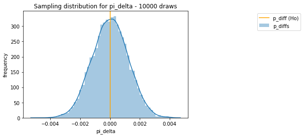

```python
p_diffs=np.array(p_diffs)
sns.distplot(p_diffs, label = 'p_diffs')
p_diff = p_new - p_old
plt.axvline(p_diff, color='orange', label='p_diff (Ho)')
plt.title('Sampling distribution for pi_delta - 10000 draws')
plt.xlabel('pi_delta')
plt.ylabel('frequency')
plt.legend(loc='best', bbox_to_anchor=(1.7, 1.0));
```

**Answer**:

Yes.

First of all and being $n_{old}$ and $n_{new}$ large, our sampling distributions for $\pi_{old}$ and $\pi_{new}$ converge in probability into a Gaussian by the CLT (loosely speaking). Being $\Pi_{\Delta}$ a linear combination of the other two, it is distributed as a Gaussian as well.

Therefore, we expected $\pi_{old}$ and $\pi_{new}$ to converge towards the overal conversion rate of our dataset, or, equally said, $\pi_{\Delta} \stackrel{p}{\rightarrow} 0$.

As expected, $\Pi_{\Delta}$ is centered around the zero and shows a Bell-shaped curve.

Moreover, our reference value, $p_{diff}$ (Part II, 2. g), has been calculated under the null as well. Indeed, its value matches the mean value of $\pi_{\Delta}$.

j. What proportion of the **p_diffs** are greater than the actual difference observed in **ab_data.csv**?

In order to answer this question, we need to calculate the value for $p_{diff}$ in the dataset first.

```python
n_old = df2.query('landing_page == "old_page"').user_id.count()
n_new = df2.query('landing_page == "new_page"').user_id.count()

convert_old = df2.query('converted == 1 and landing_page == "old_page"').user_id.count()
convert_new = df2.query('converted == 1 and landing_page == "new_page"').user_id.count()

p_diff = (convert_new/n_new) - (convert_old/n_old)
```

```python
p_diff
```

```
-0.0015782389853555567
```

```python
(p_diffs > p_diff).mean()
```

```
0.9048
```

k. In words, explain what you just computed in part **j.** What is this value called in scientific studies? What does this value mean in terms of whether or not there is a difference between the new and old pages?

**Answer**:

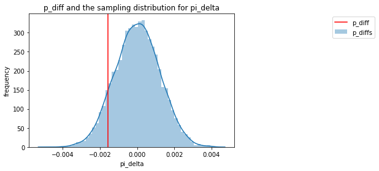

```python
sns.distplot(p_diffs, label='p_diffs')
plt.axvline(p_diff, color='r', label='p_diff')
plt.title('p_diff and the sampling distribution for pi_delta')
plt.xlabel('pi_delta')
plt.ylabel('frequency')
plt.legend(loc='best', bbox_to_anchor=(1.7, 1.0));
```

This is the probability of picking up a value for $\pi_{\Delta}$ from $\Pi_{\Delta}$ that is greater than the $p_{diff}$ observed in our data set.

Generally, the p-value is the probability of obtaining observations from the sampling distribution that are at least (or more) extreme as the results actually observed (in this case, $p_{diff}$), by assuming that the null hypothesis is 'true' - i.e. that the observations come indeed from the underlying distribution.

This p-value tells us that the probability of observing greter values of $\pi_{\Delta}$ than $p_{diff}$ is about 91%.

Concerning the question '[w]hat does this value mean in terms of whether or not there is a difference between the new and old pages', we can say that $p_{diff}$ is in accordance with our our initial $H_0$ ($p_{diff}$ shows a value for $\pi_{\Delta}$ that is $< 0$) - i.e. there is **no evidence of a preference for the new page**. Therefore, we can**not** reject the $H_0$ in favor of $H_1$.

l. We could also use a built-in to achieve similar results. Though using the built-in might be easier to code, the above portions are a walkthrough of the ideas that are critical to correctly thinking about statistical significance. Fill in the below to calculate the number of conversions for each page, as well as the number of individuals who received each page. Let $n_{old}$ and $n_{new}$ refer the the number of rows associated with the old page and new pages, respectively.

```python
import statsmodels.api as sm

print('Nr. of individuals receiving the old page: ', n_old)
print('Nr. of individuals receiving the new page: ', n_new)
print('Nr. of conversions for the old page: ', convert_old)
print('Nr. of conversions for the old page: ', convert_new)
```

```
Nr. of individuals receiving the old page:  145274
Nr. of individuals receiving the new page:  145310
Nr. of conversions for the old page:  17489
Nr. of conversions for the old page:  17264
```

m. Now use `stats.proportions_ztest` to compute your test statistic and p-value. [Here](http://knowledgetack.com/python/statsmodels/proportions_ztest/) is a helpful link on using the built in.

```python
count = np.array([convert_new, convert_old])
nobs = np.array([n_new, n_old])

z_stat, z_p_val = sm.stats.proportions_ztest(count, nobs, value = 0, alternative='larger')
```

We specify 'value = 0', for we want to performa a one-sided test with our two samples.

Then we have to list proportions and nobs by putting 'new_page'-values first and 'old_page'-values in second place.

From the docs, 'value' parameter:

> "In the case of a two-sample test, the null hypothesis is that prop[0] - prop[1] = value, where prop is the proportion in the two samples. If not provided value = 0 and the null is prop[0] = prop[1]".

Concerning the 'alternative' parameter:

> "In the two sample test, smaller means that the alternative hypothesis is p1 < p2 and larger means p1 > p2 where p1 is the proportion of the first sample and p2 of the second one."

([Reference - Satsmodels Documentation](https://www.statsmodels.org/stable/generated/statsmodels.stats.proportion.proportions_ztest.html))

```python
z_stat
```

```
-1.3109241984234394
```

```python
z_p_val
```

```
0.9050583127590245
```

n. What do the z-score and p-value you computed in the previous question mean for the conversion rates of the old and new pages? Do they agree with the findings in parts **j.** and **k.**?

**Answer**

Basically, we tested whether the difference in proportions is significatively greater than zero (actual $H_o$ of the test, for we have set the 'alternative' parameter as 'larger').

'z_stat' is the value of the standard score:

> "In statistics, the standard score is the number of standard deviations by which the value of a raw score (i.e., an observed value or data point) is above or below the mean value of what is being observed or measured". ([Reference - Standard Score Wiki](https://en.wikipedia.org/wiki/Standard_score))

Its p-value `z_p_val` is the probability of greater values of $\pi_{\Delta}$ than the the difference in proportions from the dataset.

This p-value tells us that our $H_o$ cannot be rejected for any meaningful $\alpha$ - i.e. there is evidence of **no preference** for the new page.

**Yes**, this finding is in line with those in parts **j.** and **k.**.

### Part III - A regression approach

`1.` In this final part, you will see that the result you acheived in the previous A/B test can also be acheived by performing regression.

a. Since each row is either a conversion or no conversion, what type of regression should you be performing in this case?

**Answer**: We should perform a logistic regression - $i.e.$ apply a Logit model, for our dependent variable is categorical and binary.

b. The goal is to use **statsmodels** to fit the regression model you specified in part **a.** to see if there is a significant difference in conversion based on which page a customer receives. However, you first need to create a column for the intercept, and create a dummy variable column for which page each user received. Add an **intercept** column, as well as an **ab_page** column, which is 1 when an individual receives the **treatment** and 0 if **control**.

We can work on a copy of our data frame, so that we have a backup, in case we will need the old dataframe.

```python
df3 = df2.copy()
```

```python
df3.head()
```

|  | user_id | timestamp | group | landing_page | converted |
| --- | --- | --- | --- | --- | --- |
| 0 | 851104 | 2017-01-21 22:11:48.556739 | control | old_page | 0 |
| 1 | 804228 | 2017-01-12 08:01:45.159739 | control | old_page | 0 |
| 2 | 661590 | 2017-01-11 16:55:06.154213 | treatment | new_page | 0 |
| 3 | 853541 | 2017-01-08 18:28:03.143765 | treatment | new_page | 0 |
| 4 | 864975 | 2017-01-21 01:52:26.210827 | control | old_page | 1 |

We create now the intercept and the dummy variables. Thereafter, we will remove one of the dummies, in order to avoid perfect multicollinearity.

```python
df3['intercept'] = 1

df3[['no_ab', 'ab_page']] = pd.get_dummies(df3['group'])
```

```python
df3.drop('no_ab', axis = 1, inplace = True)
```

```python
df3.head()
```

|  | user_id | timestamp | group | landing_page | converted | intercept | ab_page |
| --- | --- | --- | --- | --- | --- | --- | --- |
| 0 | 851104 | 2017-01-21 22:11:48.556739 | control | old_page | 0 | 1 | 0 |
| 1 | 804228 | 2017-01-12 08:01:45.159739 | control | old_page | 0 | 1 | 0 |
| 2 | 661590 | 2017-01-11 16:55:06.154213 | treatment | new_page | 0 | 1 | 1 |
| 3 | 853541 | 2017-01-08 18:28:03.143765 | treatment | new_page | 0 | 1 | 1 |
| 4 | 864975 | 2017-01-21 01:52:26.210827 | control | old_page | 1 | 1 | 0 |

We can check that each row marked with 1 under the column 'ab_page' belongs indeed to the 'treatment' group, and that the number of records in each subset is the same. We repeat this check for the 'control' group and 'ab_page' = 0.

```python
treatment_index = df3.query('group == "treatment"').index
ab_page_is_1_index = df3.query('ab_page == 1').index
len(treatment_index) == len(ab_page_is_1_index) == (treatment_index == ab_page_is_1_index).sum()
```

```
True
```

```python
control_index = df3.query('group == "control"').index
ab_page_is_0_index = df3.query('ab_page == 0').index
len(control_index) == len(ab_page_is_0_index) == (control_index == ab_page_is_0_index).sum()
```

```
True
```

Both index comparison are successful.

c. Use **statsmodels** to import your regression model. Instantiate the model, and fit the model using the two columns you created in part **b.** to predict whether or not an individual converts.

```python
logit_model = sm.Logit(df3['converted'], df3[['intercept', 'ab_page']])
result = logit_model.fit()
```

```
Optimization terminated successfully.
         Current function value: 0.366118
         Iterations 6
```

d. Provide the summary of your model below, and use it as necessary to answer the following questions.

```python
result.summary()
```

Logit Regression Results

| Dep. Variable: | converted | No. Observations: | 290584 |
| --- | --- | --- | --- |
| Model: | Logit | Df Residuals: | 290582 |
| Method: | MLE | Df Model: | 1 |
| Date: | Wed, 01 Jul 2020 | Pseudo R-squ.: | 8.077e-06 |
| Time: | 23:35:21 | Log-Likelihood: | -1.0639e+05 |
| converged: | True | LL-Null: | -1.0639e+05 |
| Covariance Type: | nonrobust | LLR p-value: | 0.1899 |

|  | coef | std err | z | P>\|z\| | [0.025 | 0.975] |
| --- | --- | --- | --- | --- | --- | --- |
| intercept | -1.9888 | 0.008 | -246.669 | 0.000 | -2.005 | -1.973 |
| ab_page | -0.0150 | 0.011 | -1.311 | 0.190 | -0.037 | 0.007 |

```python
result.predict().mean()
```

```
0.11959708724499626
```

The mean of the predicted values matches the probability of conversion that we have calculated in Part I, 4. a.

e. What is the p-value associated with **ab_page**? Why does it differ from the value you found in **Part II**?  
**Hint**: What are the null and alternative hypotheses associated with your regression model, and how do they compare to the null and alternative hypotheses in the **Part II**?

**Answer**

The p-value associated with the `ab_page` coefficient (let us call the coefficient $\beta_{ab\_page}$) is 0.190.

Concerning the null hypothses, we have here two pairs of null an alternative hypotheses - one for the intercept and one for `ab_page`

For instance, the null and the alternative hypotheses for $\beta_{ab\_page}$ are:

$H_0$: $\beta_{ab\_page} \stackrel{!}{=} \beta_{ab\_page, o} := 0$ $\rightarrow$ $\beta_{ab\_page} - \beta_{ab\_page, o} \stackrel{!}{=} 0$

$H_1$: $\beta_{ab\_page} \neq \beta_{ab\_page, o} := 0$ $\rightarrow$ $\beta_{ab\_page} - \beta_{ab\_page, o} \neq 0$

where $\beta_{ab\_page, o}$ is the value of $\beta_{ab\_page}$ under the null.

The p-value associated with $\beta_{ab\_page}$ is the probability of more extreme z-values in the tails (for this is a two-sided test) of the distribution of $\beta_{ab\_page} - \beta_{ab\_page, o}$ under the null, with respect of the z statistic computed.

Therefore, we can reject $H_0$, if the p-value is smaller than our $\alpha$.

**Model 1 - Results**

According to this Logit model, $\beta_{ab\_page}$ is indeed not significative. Its p-value is greater than any $\alpha$ < 0.19.

Hence, we can**not** reject the null - meaning, there is no evidence of an effect of the new page on the probability of conversion.

Moreover and accordingly, the pseudo-$R^2$ is equal to zero - $i.e.$ the restrictions imposed on the coefficients (in this case, same $H_o$ as above, plus a similar $H_o$ for the intercept) do not 'bite' (meaning, restricted model and unrestricted model perform similarily).

However, we will not focus on the pseudo-$R^2$ in what follows, for it has no 'straightforward' interpretation, due to the nonlinearity of the model.

Compared to the conclusions in Part II, 2.m, the results are (*lato sensu*) concordant. Of course, we cannot expect exactly the same numerical values, for ($e.g.$):

1. the object of interest is not the same. We have specified $H_0$ in terms of conversion rates (Part II), rather than coefficients of a binary variable (Part III);
2. the null for $\beta_{ab\_page}$ is expressed in such a way that a two-sided test is needed, while the test was one-sided in Part II;
3. the method used is not the same (we used bootstrapping, where here we use regression on an explicit logistic model, optimized numerically by ML;
4. Even though $\pi_{\Delta}$ and $\beta_{ab\_page}$ should be both Normally distributed, it is highly unlikely that their distributions share the same moments.

[Reference - Logit Results Analysis](https://stats.idre.ucla.edu/stata/output/logistic-regression-analysis/);

[Reference2 - What are pseudo R-squareds](https://stats.idre.ucla.edu/other/mult-pkg/faq/general/faq-what-are-pseudo-r-squareds/).

f. Now, you are considering other things that might influence whether or not an individual converts. Discuss why it is a good idea to consider other factors to add into your regression model. Are there any disadvantages to adding additional terms into your regression model?

```python
df2.head()
```

|  | user_id | timestamp | group | landing_page | converted |
| --- | --- | --- | --- | --- | --- |
| 0 | 851104 | 2017-01-21 22:11:48.556739 | control | old_page | 0 |
| 1 | 804228 | 2017-01-12 08:01:45.159739 | control | old_page | 0 |
| 2 | 661590 | 2017-01-11 16:55:06.154213 | treatment | new_page | 0 |
| 3 | 853541 | 2017-01-08 18:28:03.143765 | treatment | new_page | 0 |
| 4 | 864975 | 2017-01-21 01:52:26.210827 | control | old_page | 1 |

**Answer**

We can imagine that users that converted later have had more time to get acquainted to the new page (and/or that initial user suffered from aversion to the new page).

Therefore, we could control for the time stamp (by transforming it into a continuous variable) and see whether

1. its coefficient is significant;
2. $\beta_{ab\_page}$ becomes then significant (for 'timestamp' may capture some of the variability, thus making $\beta_{ab\_page}$ less biased).

If the time stamp turns out to be significative, it will be a good idea to run the experiment longer.

g. Now along with testing if the conversion rate changes for different pages, also add an effect based on which country a user lives. You will need to read in the **countries.csv** dataset and merge together your datasets on the approporiate rows. [Here](https://pandas.pydata.org/pandas-docs/stable/generated/pandas.DataFrame.join.html) are the docs for joining tables.

Does it appear that country had an impact on conversion? Don't forget to create dummy variables for these country columns - **Hint: You will need two columns for the three dummy variables.** Provide the statistical output as well as a written response to answer this question.

We import the data.

```python
countries_df = pd.read_csv('./countries.csv')
```

Dataset overview:

```python
countries_df.head()
```

|  | user_id | country |
| --- | --- | --- |
| 0 | 834778 | UK |
| 1 | 928468 | US |
| 2 | 822059 | UK |
| 3 | 711597 | UK |
| 4 | 710616 | UK |

Let us check the distinct countries.

```python
countries_df['country'].unique()
```

```
array(['UK', 'US', 'CA'], dtype=object)
```

Joining the two datasets

```python
df_new = countries_df.set_index('user_id').join(df3.set_index('user_id'), how='inner')
```

```python
df_new.head()
```

| user_id | country | timestamp | group | landing_page | converted | intercept | ab_page |
| --- | --- | --- | --- | --- | --- | --- | --- |
| 834778 | UK | 2017-01-14 23:08:43.304998 | control | old_page | 0 | 1 | 0 |
| 928468 | US | 2017-01-23 14:44:16.387854 | treatment | new_page | 0 | 1 | 1 |
| 822059 | UK | 2017-01-16 14:04:14.719771 | treatment | new_page | 1 | 1 | 1 |
| 711597 | UK | 2017-01-22 03:14:24.763511 | control | old_page | 0 | 1 | 0 |
| 710616 | UK | 2017-01-16 13:14:44.000513 | treatment | new_page | 0 | 1 | 1 |

We can now create the dummy variables for each country.

```python
df_new[['CA', 'UK', 'US']] = pd.get_dummies(df_new['country'])
```

```python
df_new.head()
```

| user_id | country | timestamp | group | landing_page | converted | intercept | ab_page | CA | UK | US |
| --- | --- | --- | --- | --- | --- | --- | --- | --- | --- | --- |
| 834778 | UK | 2017-01-14 23:08:43.304998 | control | old_page | 0 | 1 | 0 | 0 | 1 | 0 |
| 928468 | US | 2017-01-23 14:44:16.387854 | treatment | new_page | 0 | 1 | 1 | 0 | 0 | 1 |
| 822059 | UK | 2017-01-16 14:04:14.719771 | treatment | new_page | 1 | 1 | 1 | 0 | 1 | 0 |
| 711597 | UK | 2017-01-22 03:14:24.763511 | control | old_page | 0 | 1 | 0 | 0 | 1 | 0 |
| 710616 | UK | 2017-01-16 13:14:44.000513 | treatment | new_page | 0 | 1 | 1 | 0 | 1 | 0 |

Let us check that the mapping has been done correctly.

```python
df_new.query("country == 'CA'").count().size == df_new.query("CA == 1").count().size
```

```
True
```

```python
df_new.query("country == 'UK'").count().size == df_new.query("UK == 1").count().size
```

```
True
```

```python
df_new.query("country == 'US'").count().size == df_new.query("US == 1").count().size
```

```
True
```

In order to avoid perfect multicollinearity, we get rid of the UK column - i.e. we assume that by default a user lives in the UK (dummy US and CA both equal 0).

```python
df_new.drop('UK', axis = 1, inplace = True)
```

```python
df_new.head()
```

| user_id | country | timestamp | group | landing_page | converted | intercept | ab_page | CA | US |
| --- | --- | --- | --- | --- | --- | --- | --- | --- | --- |
| 834778 | UK | 2017-01-14 23:08:43.304998 | control | old_page | 0 | 1 | 0 | 0 | 0 |
| 928468 | US | 2017-01-23 14:44:16.387854 | treatment | new_page | 0 | 1 | 1 | 0 | 1 |
| 822059 | UK | 2017-01-16 14:04:14.719771 | treatment | new_page | 1 | 1 | 1 | 0 | 0 |
| 711597 | UK | 2017-01-22 03:14:24.763511 | control | old_page | 0 | 1 | 0 | 0 | 0 |
| 710616 | UK | 2017-01-16 13:14:44.000513 | treatment | new_page | 0 | 1 | 1 | 0 | 0 |

A short check:

```python
df_new.query("country == 'UK'").count().size == df_new.query("US == 0 and CA == 0").count().size
```

```
True
```

We can now specify the new model with countries, an then fit it.

```python
logit_model_country = sm.Logit(df_new['converted'], df_new[['intercept', 'ab_page', 'CA', 'US']])
result_country = logit_model_country.fit()
```

```
Optimization terminated successfully.
         Current function value: 0.366113
         Iterations 6
```

```python
result_country.summary()
```

Logit Regression Results

| Dep. Variable: | converted | No. Observations: | 290584 |
| --- | --- | --- | --- |
| Model: | Logit | Df Residuals: | 290580 |
| Method: | MLE | Df Model: | 3 |
| Date: | Wed, 01 Jul 2020 | Pseudo R-squ.: | 2.323e-05 |
| Time: | 23:35:22 | Log-Likelihood: | -1.0639e+05 |
| converged: | True | LL-Null: | -1.0639e+05 |
| Covariance Type: | nonrobust | LLR p-value: | 0.1760 |

|  | coef | std err | z | P>\|z\| | [0.025 | 0.975] |
| --- | --- | --- | --- | --- | --- | --- |
| intercept | -1.9794 | 0.013 | -155.415 | 0.000 | -2.004 | -1.954 |
| ab_page | -0.0149 | 0.011 | -1.307 | 0.191 | -0.037 | 0.007 |
| CA | -0.0506 | 0.028 | -1.784 | 0.074 | -0.106 | 0.005 |
| US | -0.0099 | 0.013 | -0.743 | 0.457 | -0.036 | 0.016 |

```python
1/np.exp(-0.0506)
```

```
1.0519020483004984
```

**Model 2 - Results**

$\beta_{ab\_page}$ remains non significative and negative. Its value and p-value remained more or less the same as in the previous model.

The coefficient for 'CA' is significant at $\alpha$ = 10%, but not at $\alpha$ = 5%. Its interpretation is: for a user living in Canada, the probability of converting is 1.05 times lower, *caeteris paribus*.

The coefficient for 'US' is not significative.

It seems like there is a certain difference for users located in Canada, whereas users in the UK and in the US do not differ much in this respect.

Overall, the pseudo-$R^2$ has increased - meaning that restrictions imposed on the coefficients under the null start to 'bite' a (little) bit more.

h. Though you have now looked at the individual factors of country and page on conversion, we would now like to look at an interaction between page and country to see if there significant effects on conversion. Create the necessary additional columns, and fit the new model.

Provide the summary results, and your conclusions based on the results.

```python
df_new['page_CA'] = df_new['ab_page']*df_new['CA']
```

```python
df_new['page_US'] = df_new['ab_page']*df_new['US']
```

```python
df_new.head()
```

| user_id | country | timestamp | group | landing_page | converted | intercept | ab_page | CA | US | page_CA | page_US |
| --- | --- | --- | --- | --- | --- | --- | --- | --- | --- | --- | --- |
| 834778 | UK | 2017-01-14 23:08:43.304998 | control | old_page | 0 | 1 | 0 | 0 | 0 | 0 | 0 |
| 928468 | US | 2017-01-23 14:44:16.387854 | treatment | new_page | 0 | 1 | 1 | 0 | 1 | 0 | 1 |
| 822059 | UK | 2017-01-16 14:04:14.719771 | treatment | new_page | 1 | 1 | 1 | 0 | 0 | 0 | 0 |
| 711597 | UK | 2017-01-22 03:14:24.763511 | control | old_page | 0 | 1 | 0 | 0 | 0 | 0 | 0 |
| 710616 | UK | 2017-01-16 13:14:44.000513 | treatment | new_page | 0 | 1 | 1 | 0 | 0 | 0 | 0 |

```python
logit_model_country_interaction = sm.Logit(df_new['converted'], df_new[['intercept', 'ab_page', 'page_CA', 'page_US']])
result_country_interaction = logit_model_country_interaction.fit()
```

```
Optimization terminated successfully.
         Current function value: 0.366109
         Iterations 6
```

```python
result_country_interaction.summary()
```

Logit Regression Results

| Dep. Variable: | converted | No. Observations: | 290584 |
| --- | --- | --- | --- |
| Model: | Logit | Df Residuals: | 290580 |
| Method: | MLE | Df Model: | 3 |
| Date: | Wed, 01 Jul 2020 | Pseudo R-squ.: | 3.351e-05 |
| Time: | 23:35:23 | Log-Likelihood: | -1.0639e+05 |
| converged: | True | LL-Null: | -1.0639e+05 |
| Covariance Type: | nonrobust | LLR p-value: | 0.06785 |

|  | coef | std err | z | P>\|z\| | [0.025 | 0.975] |
| --- | --- | --- | --- | --- | --- | --- |
| intercept | -1.9888 | 0.008 | -246.669 | 0.000 | -2.005 | -1.973 |
| ab_page | 0.0074 | 0.018 | 0.410 | 0.682 | -0.028 | 0.043 |
| page_CA | -0.0901 | 0.040 | -2.225 | 0.026 | -0.169 | -0.011 |
| page_US | -0.0257 | 0.019 | -1.363 | 0.173 | -0.063 | 0.011 |

```python
1/np.exp(-0.0901)
```

```
1.0942837066046347
```

**Model 3 - Results**

Given that a user has visited the new page, we have:

1. Probability of conversion in the U.K.

   The $\beta_{ab\_page}$ turns now positive, but remains non significative. Its p-value is very big.
1. Probability of conversion in Canada

   The coefficient for 'page_CA' is significant at $\alpha$ = 5%. Its interpretation is: for a user living in Canada, the probability of converting is 1.09 times lower, *caeteris paribus*.
1. Probability of conversion in the U.S.

   The coefficient for 'page_US' is negative and non significative.

**Conclusion**

There is evidence of **no significance** of the new page on the conversion in the UK and in the US.

We can check that results are still significative by removing 'page_US' and 'ab_page':

```python
logit_model_country_interaction_2 = sm.Logit(df_new['converted'], df_new[['intercept', 'page_CA']])
result_country_interaction_2 = logit_model_country_interaction_2.fit()
```

```
Optimization terminated successfully.
         Current function value: 0.366114
         Iterations 6
```

```python
result_country_interaction_2.summary()
```

Logit Regression Results

| Dep. Variable: | converted | No. Observations: | 290584 |
| --- | --- | --- | --- |
| Model: | Logit | Df Residuals: | 290582 |
| Method: | MLE | Df Model: | 1 |
| Date: | Wed, 01 Jul 2020 | Pseudo R-squ.: | 2.016e-05 |
| Time: | 23:35:23 | Log-Likelihood: | -1.0639e+05 |
| converged: | True | LL-Null: | -1.0639e+05 |
| Covariance Type: | nonrobust | LLR p-value: | 0.03834 |

|  | coef | std err | z | P>\|z\| | [0.025 | 0.975] |
| --- | --- | --- | --- | --- | --- | --- |
| intercept | -1.9944 | 0.006 | -344.689 | 0.000 | -2.006 | -1.983 |
| page_CA | -0.0771 | 0.038 | -2.052 | 0.040 | -0.151 | -0.003 |

```python
1/np.exp(-0.0771)
```

```
1.08015008600063
```

**Model 4 - Results**

Now, the coefficient for 'page_CA' is significant at $\alpha$ = 5%, but not at $\alpha$ = 1%. Its interpretation is: for a user living in Canada, the probability of converting is 1.08 times lower, *caeteris paribus*.

We can conclude by stating that the effect of the new page on conversions is indeed non significative for users located in the UK and in the US.

Users located in Canada seems to have a preference for the old page - $i.e.$ the new page leads to a lower probability of conversion in Canada.

## Conclusions

We have investigated the relation between the page being displayed to a user and the frequency of conversion in our data set 'ab_data.csv'.

In Part I, we have constructed a statstic of the probability of conversion, given the page visited. We have not found sufficient evidence to claim that the new page leads to more conversions. Conversely, we observed a slightly higher conversion frequency within the control group (12.04%; old page) than in the experiment group (11.88%, new page).

In Part II, we have performed an A/B Test for the difference in conversion rates between pages against a sampling distribution of the same difference, which has been obtained by bootstrapping our data set under the null of no positive 'new-page' effect.

In the first place, we have validated the consistency of the so-obtained sampling distribution mean to our expected value under the null hypothesis, as specified in Part II, 1.

In the second place, we have compared our statistic $p_{diff}$ with the reference parameter $\pi_{\Delta}$. We have found that $p_{diff}$ is consistent with the null hypotesis. Therefore, there is no evidence in favour of claiming that the new page leads to a higher conversion rate.

We have validated this result by performing a 'Proportions z-Test'. This test provied concordant results to the ones mentioned above.

In Part III, we applied regression techniques on explicit Logit models.

On a first model, we have assessed the effect of a page on the probability of conversion. Although not signficant, the estimation of $\beta_{ab\_page}$ was negative. Both, the non-significance of $\beta_{ab\_page}$ and the negativity of its estimated value, are concorant with the results in Part II. We then suggested to add the time stamp to the model, in oder to control for possible aversion (of old users) to the new page. If the time stamp turns out to be significative, it will be a good idea to run the experiment longer.

A second model included data on user residency. We have assessed the effect of three countries of origin on the probability of conversion. The estimate of $\beta_{ab\_page}$ was still non significative and negative. However, the model highlighted a negative relation between the dependent variable and the country for users located in Canada, whereas this relation was not significative for users from the UK and from the US.

We have then focused on the interaction between page and country. We assessed these interactions in a third model and found out that the cross effect of new page and country was significant for Canada, but not for UK and USA.

Finally, we computed a last model (fourth), by considering just the interaction between the new page and residency in Canada. The interaction coefficient for the new page and Canada was negaive and significant at 5%. This model provides evidence that the probability of converting is 1.08 times lower for a user living in Canada and viewing the new page, $caeteris$ $paribus$.

Generally, the results obtained in Part I, Part II and Part III are concordant on two claims.

Consequently, we suggest to run the experiment longer and assess the effect of the time stamps on the probability of conversion. If this is not possible, the evidence gathered until now suggests to keep the old page.